# Introduction to transformr

Derek Damron

2016-07-09

## What is transformr?

*transformr*, as you might have guessed, is an R package that helps you easily transform your variables.

So why should you consider using *transformr* for your data analysis work?

1. **Robustness**: All of the functions within *transformr* have been loaded with argument checks, unit tests, and informative error messages so good luck trying to break them! (But, by all means, do try to break them and then [create an issue so we can fix what’s broken](https://github.com/derek-damron/transformr/issues/new)!)
2. **Convenience**: Could you write functions to do these transformations? Absolutely, but why bother when it’s already been done for you?

This introductory vignette provides a brief description of the functions provided by *transformr* along with some simple examples. Please refer to the function documentation (e.g. `?trim` or `help(trim)`) for more technical information on each of these functions.

## trim()

Trimming handles outliers in your numeric variable.

A common use of `trim` is “capping” a numeric variable to reduce the effect of high-valued outliers on predictive algorithms. For example, imagine that we have a variable `x` that looks like this:

```r
x <- c(1, 1, 1, 2, 6)
```

The last value of 6 is noticably higher than the rest of the values, so depending on the context we might want to do one of the following:

- “Round” the outlying value of 6 down to the next highest value of 2
- Convert the outlying value of 6 to `NA` (e.g. if the high value of 6 indicates a data quality issue)

`trim` allows you quickly and easily do these types of transformations.

```r
# "Round" to 2
trim(x, hi=2)
```

```
## [1] 1 1 1 2 2
```

```r
# Convert to NA
trim(x, hi=2, replace=NA)
```

```
## [1]  1  1  1  2 NA
```

The table below shows how these different versions of `x` compare with each other, where the values that have changed from `x` are *bolded*.

| x | “Round” to 2 | Convert to NA |
| --- | --- | --- |
| 1 | 1 | 1 |
| 1 | 1 | 1 |
| 1 | 1 | 1 |
| 2 | 2 | 2 |
| 6 | *2* | *NA* |

You can also easily trim via percentiles by adding the argument `method="percentile"`. Check out `trim`’s documentation (`?trim`) for some more examples on using `trim`!

## rescale()

Rescaling, well, rescales your numeric variables.

Common uses of rescaling are to make a variable mimic a standard normal distribution or to make a variable lie between two specific values. For example, imagine that we have a variable `x` that is approximately normal with a mean of -3 and a standard deviation of 1/2:

```r
set.seed(666)
size <- 1e4
x <- rnorm(size, mean=-3, sd=1/2)
```

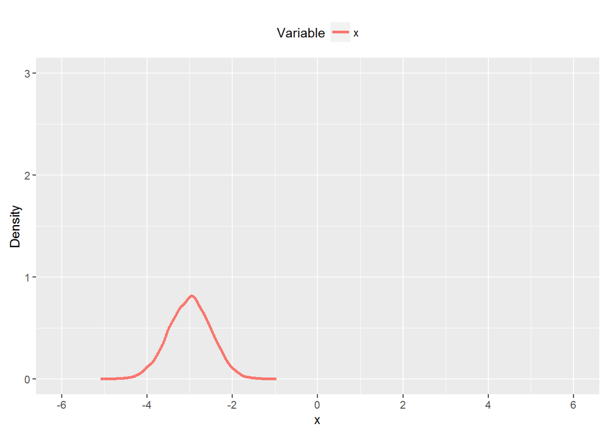

Depending on the context we might want to do one of the following:

- Rescale `x` to have a standard normal distribution
- Rescale `x` to have a minimum value of 0 and a maximum value of 1

`rescale` allows you quickly and easily do these types of transformations.

```r
# Standard normal
rescale(x)
# Between 0 and 1
rescale(x, method="minmax")
```

The graph below shows how these different versions of `x` compare with each other.

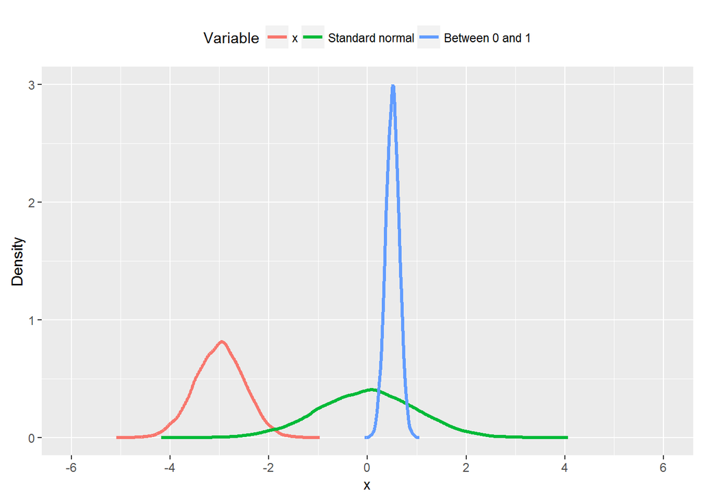

You can also easily rescale to other normal distribution (e.g. mean of 99 and standard deviation of 16) or to be between other minimum and maximum values (e.g. minimum of -132 and maximum of 89). Check out `rescale`’s documentation (`?rescale`) for some more examples on using `rescale`!

## corral()

Corralling groups together uncommon/uninteresting values of a categorical variable and “levels” the resulting factor variable.

A common use of `corral` is grouping secondary values into an “Other” category. For example, imagine that we have a variable `x` that looks like this:

```r
x <- c("Red", "Red", "Red", "Blue", "Blue", "Green", "Orange", "Pink")
```

Depending on the context we might want to do one of the following:

- Corral `x` to keep the most two common colors (Red and Blue) distinct and group all other values
- Corral `x` to keep Blue and Green distinct and group all other values
- Corral `x` to keep Blue and Green distinct and change other values to `NA`

`corral` allows you quickly and easily do these types of transformations.

```r
# Keep two most common colors distinct
corral(x, groups=3)
```

```
## [1] Red   Red   Red   Blue  Blue  Other Other Other
## Levels: Red Blue Other
```

```r
# Keep blue and green distinct
corral(x, groups=c("Blue", "Green"))
```

```
## [1] Other Other Other Blue  Blue  Green Other Other
## Levels: Blue Green Other
```

```r
# Keep blue and green distinct and change other values to NA
corral(x, groups=c("Blue", "Green"), collect=NA)
```

```
## [1] <NA>  <NA>  <NA>  Blue  Blue  Green <NA>  <NA>
## Levels: Blue Green
```

The table below shows how these different versions of `x` compare with each other, where the values that have changed from `x` are *bolded*.

| x | Two most common colors | Blue and Green | Blue and Green and others as NA |
| --- | --- | --- | --- |
| Red | Red | *Other* | *NA* |
| Red | Red | *Other* | *NA* |
| Red | Red | *Other* | *NA* |
| Blue | Blue | Blue | Blue |
| Blue | Blue | Blue | Blue |
| Green | *Other* | Green | Green |
| Orange | *Other* | *Other* | *NA* |
| Pink | *Other* | *Other* | *NA* |

You can also easily corral based on other criteria as well (e.g. level by alphabetical order rather than by size). Check out `corral`’s documentation (`?corral`) for some more examples on using `corral`!

## impute()

Imputing replaces missing values with non-missing values.

A common use of `impute` is substituting non-`NA` values for `NA` values before running a statistical or machine learning algorithm. For example, imagine that we have a variable `x` that looks like this:

```r
x <- c(1, 1, 1, 2, NA, NA)
```

Depending on the context we might want to do one of the following:

- Impute the mean of `x`
- Impute -1
- Impute “Missing”

`impute` allows you quickly and easily do these types of transformations.

```r
# Impute mean
impute(x, mean)
```

```
## [1] 1.00 1.00 1.00 2.00 1.25 1.25
```

```r
# Impute -1
impute(x, -1)
```

```
## [1]  1  1  1  2 -1 -1
```

```r
# Impute "Missing"
impute(x, "Missing")
```

```
## [1] "1"       "1"       "1"       "2"       "Missing" "Missing"
```

There are also a few `impute_*` helper functions for more sophisticated imputation.

```r
# Impute mode (i.e. most common value)
impute(x, impute_mode)
```

```
## [1] 1 1 1 2 1 1
```

```r
# Impute from ecdf
impute(x, impute_ecdf)
```

```
## [1] 1.00000 1.00000 1.00000 2.00000 1.00000 1.53081
```

```r
# Impute from resampling
impute(x, impute_sample)
```

```
## [1] 1 1 1 2 1 2
```

The table below shows how these different versions of `x` compare with each other, where the values that have changed from `x` are *bolded*.

[output not shown]

You can also easily impute based on other criteria as well (e.g. by writing your own imputation function). Check out `impute`’s documentation (`?impute`) for some more examples on using `impute`!